# RP_viscoelastic_numericalcode

## 1. Governing Equations and Integral Formulation

The radial momentum balance for an incompressible viscoelastic fluid surrounding a pulsating spherical bubble yields the Generalized Rayleigh–Plesset equation:

$$ \rho \left( R \ddot{R} + \frac{3}{2} \dot{R}^2 \right) = \Delta p - \frac{2\gamma}{R} + \int_{R}^{\infty} \left( 2\sigma_{rr} - \sigma_{\theta\theta} - \sigma_{\phi\phi} \right) \frac{\mathrm{d}r}{r} \tag{1} $$

Because bubble pulsation is spherically symmetric, the surrounding liquid expands and contracts equally in all tangential directions. Consequently, the azimuthal stress $\sigma_{\theta\theta}$ and polar stress $\sigma_{\phi\phi}$ are equal ($\sigma_{\theta\theta} = \sigma_{\phi\phi}$), simplifying the integrand in (1) to:

$$ \int_{R}^{\infty} \left( 2\sigma_{rr} - \sigma_{\theta\theta} - \sigma_{\phi\phi} \right) \frac{\mathrm{d}r}{r} = \int_{R}^{\infty} \frac{2(\sigma_{rr} - \sigma_{\theta\theta})}{r} \, \mathrm{d}r \tag{2} $$

Here, $R(t)$ denotes the instantaneous bubble radius, overdots represent temporal differentiation, $\rho$ is the fluid density, $\gamma$ is the interfacial tension coefficient, and $\Delta p = P_g(R) - P_0 - P_A(t)$ represents the dynamic pressure differential between the internal gas pressure $P_g(R)$, the static ambient pressure $P_0$, and the driving acoustic pressure $P_A(t) = -p_A \sin(2\pi f t)$ with amplitude $p_A$ and frequency $f$.

Assuming polytropic behavior for the enclosed non-condensable gas, the internal gas pressure takes the form

$$ P_g(R) = \left(P_0 + \frac{2\gamma}{R_0}\right) \left(\frac{R_0}{R}\right)^{3\kappa} \tag{3} $$

with $R_0$ denoting the equilibrium bubble radius and $\kappa$ the polytropic exponent. The quantities $\sigma_{rr}$ and $\sigma_{\theta\theta}$ represent the radial and azimuthal components of the deviatoric stress tensor $\boldsymbol{\sigma}$.

For an Upper Convected Maxwell (UCM) fluid, the stress tensor $\boldsymbol{\sigma}(t)$ is expressed as a hereditary integral over past deformation histories weighted by an exponential relaxation kernel $\psi(t)$:

$$ \boldsymbol{\sigma}(t) = \int_{-\infty}^{t} \psi(t - t') \mathbf{C}_t^{-1}(t') \, \mathrm{d}t' \tag{4} $$

where $\mathbf{C}_t^{-1}(t')$ is the Finger strain tensor relating the past state at time $t'$ to the current state at time $t$. The relaxation kernel is defined as

$$ \psi(t) = \frac{\eta}{\lambda} \exp\left(-\frac{t}{\lambda}\right) = G \exp\left(-\frac{t}{\lambda}\right) \tag{5} $$

where $\eta$ is the zero-shear dynamic viscosity ($\eta = 0.03\,\mathrm{Pa\,s}$), $\lambda = \mathrm{De}/(2\pi f)$ is the relaxation time associated with the Deborah number $\mathrm{De}$, and $G = \eta/\lambda$ denotes the elastic shear modulus.

## 2. Transition from Integral to Differential Formulation

Evaluating the memory integral at every time step requires storing the complete deformation history, scaling computationally as $\mathcal{O}(N^2)$ and encountering severe numerical instabilities during rapid, large-amplitude bubble collapses. To overcome these limitations, the integral UCM relation is transformed into its frame-invariant differential representation:

$$ \boldsymbol{\sigma} + \lambda \stackrel{\nabla}{\boldsymbol{\sigma}} = 2 \eta \mathbf{D} \tag{6} $$

where $\mathbf{D} = \frac{1}{2}\left[ \nabla \mathbf{v} + (\nabla \mathbf{v})^T \right]$ is the rate-of-deformation tensor, and $\stackrel{\nabla}{\boldsymbol{\sigma}}$ represents the upper-convected objective rate, defined as

$$ \stackrel{\nabla}{\boldsymbol{\sigma}} = \frac{\mathrm{D}\boldsymbol{\sigma}}{\mathrm{D}t} - (\nabla \mathbf{v})^T \cdot \boldsymbol{\sigma} - \boldsymbol{\sigma} \cdot (\nabla \mathbf{v}) \tag{7} $$

## 3. Kinematics and Stress Components at the Interface

Under the assumptions of fluid incompressibility and spherical symmetry, the radial velocity field $u(r,t)$ surrounding the cavity is expressed as

$$ u(r, t) = \frac{R^2 \dot{R}}{r^2} \tag{8} $$

Evaluating the velocity gradient tensor $\nabla \mathbf{v}$ at the bubble interface ($r = R$) yields

$$ \left.\nabla \mathbf{v}\right|_{r=R} = \begin{pmatrix} \frac{\partial u}{\partial r} & 0 & 0 \\ 0 & \frac{u}{r} & 0 \\ 0 & 0 & \frac{u}{r} \end{pmatrix}_{r=R} = \begin{pmatrix} -2\frac{\dot{R}}{R} & 0 & 0 \\ 0 & \frac{\dot{R}}{R} & 0 \\ 0 & 0 & \frac{\dot{R}}{R} \end{pmatrix} \tag{9} $$

Defining the interfacial elongation rate as $\dot{\varepsilon} = \dot{R}/R$, the non-zero components of the rate-of-deformation tensor become $D_{rr} = -2\dot{\varepsilon}$ and $D_{\theta\theta} = D_{\phi\phi} = \dot{\varepsilon}$. Substituting these kinematic conditions into (7), the components of the upper-convected derivative evaluate to

$$ \stackrel{\nabla}{\sigma}_{rr} = \frac{\mathrm{d}\sigma_{rr}}{\mathrm{d}t} + 4\dot{\varepsilon}\sigma_{rr} \tag{10} $$

$$ \stackrel{\nabla}{\sigma}_{\theta\theta} = \frac{\mathrm{d}\sigma_{\theta\theta}}{\mathrm{d}t} - 2\dot{\varepsilon}\sigma_{\theta\theta} \tag{11} $$

## 4. Derivation of the Differential Governing Equations

Substituting the frame-invariant derivatives (10)–(11) and strain-rate components into the UCM constitutive relation (6) isolates the explicit time derivatives of the radial and azimuthal stresses:

$$ \frac{\mathrm{d}\sigma_{rr}}{\mathrm{d}t} = -4G\left(\frac{\dot{R}}{R}\right) - \frac{\sigma_{rr}}{\lambda} - 4\left(\frac{\dot{R}}{R}\right)\sigma_{rr} \tag{12} $$

$$ \frac{\mathrm{d}\sigma_{\theta\theta}}{\mathrm{d}t} = 2G\left(\frac{\dot{R}}{R}\right) - \frac{\sigma_{\theta\theta}}{\lambda} + 2\left(\frac{\dot{R}}{R}\right)\sigma_{\theta\theta} \tag{13} $$

Performing the spatial integration of the normal stress difference across the liquid domain reduces the integral term in (2) to interface-evaluated quantities:

$$ \int_{R}^{\infty} \frac{2(\sigma_{rr} - \sigma_{\theta\theta})}{r} \, \mathrm{d}r = \sigma_{rr}(R) - \sigma_{\theta\theta}(R) \tag{14} $$

Re-inserting this result into (1) provides the explicit expression for the interface acceleration $\ddot{R}$:

$$ \ddot{R} = \frac{1}{\rho R} \left[ P_g(R) - P_0 - P_A(t) - \frac{2\gamma}{R} + (\sigma_{rr} - \sigma_{\theta\theta}) - \frac{1}{2}\rho \dot{R}^2 \right] \tag{15} $$

## 5. Coupled First-Order ODE System

The non-local integral formulation is thus reduced to a system of four stiff, coupled first-order Ordinary Differential Equations suitable for time-marching integration schemes:

$$ \frac{\mathrm{d}}{\mathrm{d}t} \begin{pmatrix} R \\[4pt] \dot{R} \\[4pt] \sigma_{rr} \\[4pt] \sigma_{\theta\theta} \end{pmatrix} = \begin{pmatrix} \dot{R} \\[4pt] \frac{1}{\rho R} \left[ P_g(R) - P_0 - P_A(t) - \frac{2\gamma}{R} + (\sigma_{rr} - \sigma_{\theta\theta}) - \frac{1}{2}\rho \dot{R}^2 \right] \\[4pt] -4G\left(\frac{\dot{R}}{R}\right) - \frac{\sigma_{rr}}{\lambda} - 4\left(\frac{\dot{R}}{R}\right)\sigma_{rr} \\[4pt] 2G\left(\frac{\dot{R}}{R}\right) - \frac{\sigma_{\theta\theta}}{\lambda} + 2\left(\frac{\dot{R}}{R}\right)\sigma_{\theta\theta} \end{pmatrix} \tag{16} $$

We first import the dependencies for numerical computation, integration, and visualization. $\textcolor{magenta}{numpy}$ handles vector operations and mathematical constants, $\textcolor{magenta}{\texttt{scipy.integrate.solve\_ivp}}$ provides the $\textcolor{magenta}{adaptive \;initial \;value \;problem\; solver \;Radau}$ used to integrate the differential equations, and $\textcolor{magenta}{matplotlib.pyplot}$ is used to render the dimensionless dynamic response plots.

```python
import matplotlib.pyplot as plt
import numpy as np
from scipy.integrate import solve_ivp
```

This block sets up the physical fluid properties ($\rho, \gamma, \eta$), acoustic driving parameters ($f = 3\text{ MHz}$, $p_A = 0.4\text{ MPa}$), and initial internal polytropic gas pressure $P_{g0}$. It also establishes the evaluation time grid spanning $9$ acoustic cycles ($9/f$) sampled at $1500$ uniform intervals.

```python
# --- Physical Parameters & Time Grid ---
R0, f, pA = 1.5e-6, 3.0e6, 0.4e6
rho, gamma, eta = 1000.0, 0.072, 0.03
P0, kappa = 101325.0, 1.4
Pg0 = P0 + (2 * gamma / R0)

t_end = 9.0 / f
t_eval = np.linspace(0, t_end, 1500)
```

This subroutine encapsulates the system ODEs, dynamically selecting between the standard 2nd-order Newtonian formulation ($De = 0$) and the stiff 4th-order UCM model ($De > 0$) that couples radial motion with extra-stress rates ($\mathrm{d}\sigma_{rr}/\mathrm{d}t, \mathrm{d}\sigma_{\theta\theta}/\mathrm{d}t$). Integration is performed using the implicit Radau solver to handle numerical stiffness during bubble collapse phases.

```python
def simulate_bubble(De):
    if De == 0:
        # Classical Newtonian viscous Rayleigh-Plesset equation
        def ode(t, y):
            R, Rdot = y
            R_safe = max(R, 1e-12)

            PA = -pA * np.sin(2 * np.pi * f * t)
            Pg = Pg0 * (R0 / R_safe) ** (3 * kappa)

            Rddot = (1 / (rho * R_safe)) * (
                Pg
                - P0
                - PA
                - (2 * gamma / R_safe)
                - (4 * eta * Rdot / R_safe)
                - 0.5 * rho * Rdot**2
            )
            return [Rdot, Rddot]

        y0 = [R0, 0.0]
        sol = solve_ivp(
            ode,
            [0, t_end],
            y0,
            t_eval=t_eval,
            method="Radau",
            rtol=1e-6,
            atol=1e-8,
        )
        return sol.t, sol.y[0]

    else:
        # Upper Convective Maxwell (UCM) viscoelastic model
        lmbda = De / (2 * np.pi * f)
        G = eta / lmbda

        def ode(t, y):
            R, Rdot, tau_rr, tau_tt = y
            R_safe = max(R, 1e-12)
            strain_rate = Rdot / R_safe

            PA = -pA * np.sin(2 * np.pi * f * t)
            Pg = Pg0 * (R0 / R_safe) ** (3 * kappa)

            # Rayleigh-Plesset equation with normal stress difference (tau_rr - tau_tt)
            Rddot = (1 / (rho * R_safe)) * (
                Pg
                - P0
                - PA
                - (2 * gamma / R_safe)
                + (tau_rr - tau_tt)
                - 0.5 * rho * Rdot**2
            )

            # Correct UCM constitutive stress derivatives at bubble boundary r = R(t)
            d_tau_rr = -4.0 * G * strain_rate - (tau_rr / lmbda) - 4.0 * strain_rate * tau_rr
            d_tau_tt =  2.0 * G * strain_rate - (tau_tt / lmbda) + 2.0 * strain_rate * tau_tt

            return [Rdot, Rddot, d_tau_rr, d_tau_tt]

        y0 = [R0, 0.0, 0.0, 0.0]
        sol = solve_ivp(
            ode,
            [0, t_end],
            y0,
            t_eval=t_eval,
            method="Radau",
            rtol=1e-6,
            atol=1e-8,
        )
        return sol.t, sol.y[0]
```

This block will executes a parameter sweep over Deborah numbers ($De \in \{0, 1, 2\}$) to evaluate viscoelastic relaxation effects on cavity dynamics. It normalizes time to acoustic cycles ($ft$) and radius to equilibrium size ($R/R_0$), rendering a comparative transient response plot.

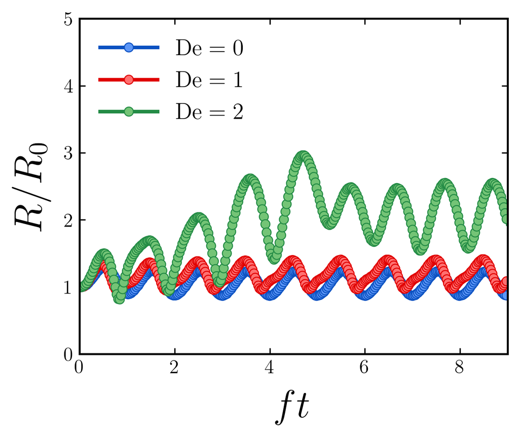

```python
plt.rcParams.update(
    {
        "text.usetex": True,
        "font.family": "serif",
        "font.serif": ["Computer Modern Roman"],
        "xtick.direction": "in",
        "ytick.direction": "in",
        "xtick.top": True,
        "ytick.right": True,
        "xtick.labelsize": 12,
        "ytick.labelsize": 12,
        "axes.linewidth": 1.2,
    }
)

# --- Color Definitions (Dark Line, Lighter Semi-Transparent Marker Face) ---
style_config = {
    0: {"line": "#0B51C1", "face": "#5C96F7"},  # Blue
    1: {"line": "#E00000", "face": "#FF7070"},  # Red
    2: {"line": "#238B45", "face": "#74C476"},  # Green
}

plt.figure(figsize=(4.5, 3.8), dpi=300)

for De in [0, 1, 2]:
    t, R = simulate_bubble(De)
    cycles = f * t  # Dimensionless time ft

    plt.plot(
        cycles,
        R / R0,
        label=rf"$\mathrm{{De}} = {De}$",
        color=style_config[De]["line"],
        linewidth=2.2,
        marker="o",
        markersize=5.5,
        markerfacecolor=style_config[De]["face"],
        markeredgecolor=style_config[De]["line"],
        markeredgewidth=0.6,
        markevery=5,  # Subsamples points to avoid overlapping markers
    )

# --- Labels and Axis Limits ---
plt.xlabel(r"$ft$", fontsize=24, labelpad=8)
plt.ylabel(r"$R/R_0$", fontsize=24, labelpad=8)
plt.xlim(0, 9)
plt.ylim(0, 5)

# --- Legend (Frameless, Match JFM Style) ---
plt.legend(loc="upper left", fontsize=14, frameon=False, handlelength=2.5)

plt.tight_layout()
plt.show()
```